# Brand Mapping Insights

# Project Overview

A survey software company (hereafter Brand C) sought to assess its market position relative to four key competitors and to evaluate consumer perceptions of eight key attributes in relation to the brand. Particular emphasis was placed on *Ease of Use*, *Data Security*, and *Data Integration*, as these attributes have been central to recent product development and marketing efforts.

Thus, this project aimed to:

- **Assess how Brand C is perceived relative to its competitors.**
- **Identify key strengths and areas for improvement across core attributes, with a focus on strategic priorities.**

# Data Source

The data for this project was collected through a survey administered by Brand C’s research team. The sample comprised 5102 respondents recruited through an online panel. The respondents rated the **five** competing brands across **eight** key attributes: *Ease of Use*, *Data Security*, *Integration*, *Data Analysis*, *Real-Time Reporting*, *Cost-Effectiveness*, *Collaboration*, and *Customization*.

**Data Structure**

- **Rows**: Brands (Brand A, Brand B, Brand C, Brand D & Brand E).
- **Columns**: Attributes (Ease of Use, Customization, etc.).
- **Values**: Count of respondents associating each attribute with a specific brand.

# Data Preparation

Brand C’s research team initially removed rows with nonsensical responses before sharing the dataset. Upon receipt, we performed a detailed inspection for missing data, inconsistencies, and anomalies. Speeders—participants who completed the survey unrealistically fast—were identified and removed [see Zhang & Conrad, 2014](https://doi.org/10.18148/srm/2014.v8i2.5453). After cleaning the data, 4,809 valid responses remained for analysis. We then created a contingency table representing the joint frequency distribution of brands and attributes. This table served as the primary input for Correspondence Analysis. The balloon plot below visualizes these relationships. Among others, the plot shows that:

- **Brand E** is the market leader.
- **Brand A** is an emerging competitor.

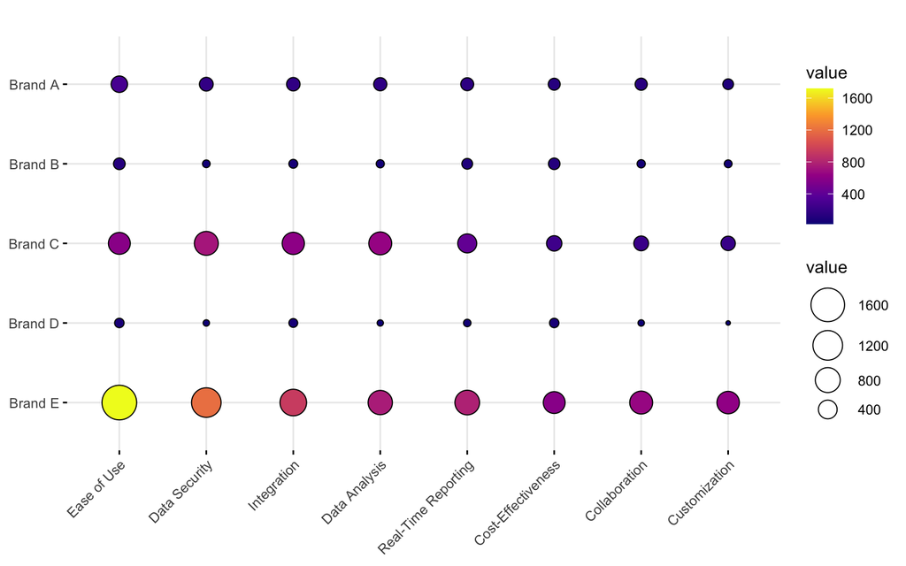

# Data Analysis

[Correspondence Analysis](https://doi.org/10.1201/9781315369983) was conducted to examine relationships between brands and attributes. This statistical method identifies patterns in brand-attribute associations thereby revealing key differentiation points within the competitive landscape. The results showed that two main dimensions explained 96.62% of the variation, meaning they capture nearly all important brand-attribute patterns. [Malinvaud’s test](https://CRAN.R-project.org/package=CAinterprTools) was applied to determine the optimal number of dimensions to retain. The results confirmed that the first two dimensions were sufficient for meaningful interpretation. The resulting perceptual map is shown below in the Insights Summary section to support interpretation.

# Insights Summary

## **Brand C’s Market Position**

**Brand C** is positioned in the top left quadrant of the perceptual map. It is closely associated with *Data Analysis*, *Data Security*, and *Integration*, as shown by its proximity to these attributes. This indicates that consumers perceive Brand C as a secure, technically robust platform with strong analytical capabilities. However, it is further from features such as *Ease of Use*, *Customization*, and *Cost-Effectiveness*, suggesting it may be perceived as less user-friendly or value-driven compared to other brands.

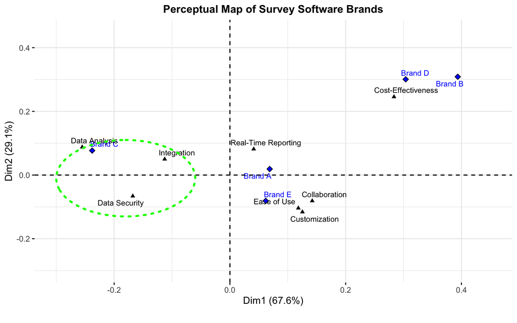

[A mosaic plot](https://CRAN.R-project.org/package=vcd.) was generated to complement the Correspondence Analysis by highlighting the strength and direction of brand-attribute relationships. This visualization helps validate and interpret the perceptual map by showing which brand-feature combinations occur more or less often than expected.

- *Larger rectangles* indicate more frequent brand-feature pairings.
- *Blue shading* shows positive associations (brand-attribute combinations appear more often than expected), while *red shading* shows negative associations (brand-attribute combinations appear less often than expected).

The mosaic plot shows that **Brand C** is positively associated with *Data Analysis*, *Data Security*, and *Integration*, indicating that consumers recognize its strengths in these areas. However, it is negatively associated with *Cost-Effectiveness*, *Ease of Use*, and *Collaboration*, suggesting that it is perceived as expensive, less user-friendly, and perhaps not ideal for teamwork.

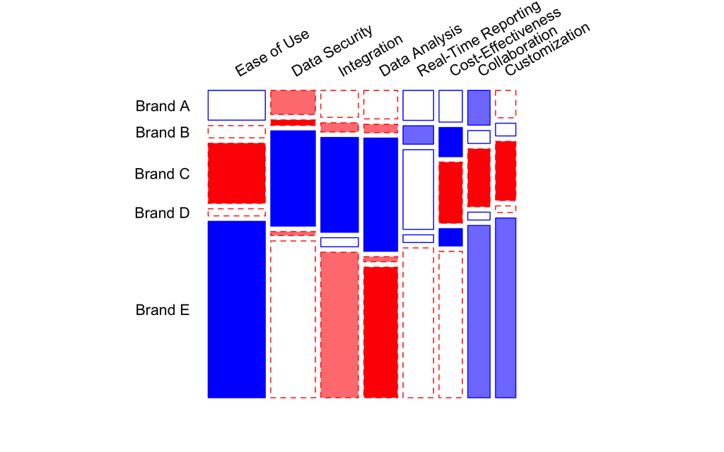

## **Competitive Landscape**

Both the perceptual map and the mosaic plot show that:

- **Brand E** is seen as intuitive and user-friendly.
- **Both Brand B** and **Brand D** are positively associated with *Cost-Effectiveness*, indicating that they are perceived as budget-friendly options in the market
- **Brand A** and **Brand E** are more aligned with attributes like *Ease of Use*, *Collaboration*, and *Customization*, suggesting that they may be viewed as more user-friendly and adaptable compared to **Brand C**.

# Recommendations

- **Emphasize** Brand C’s strengths in trust, compliance, and advanced analytics to reinforce its leadership in this space.
- **Explore** value-based pricing strategies or marketing campaigns that communicate long-term ROI.
- **Improve** the user experience through a simplified interface and a better onboarding strategy to shift perceptions around usability.
- **Make** *Data Security & Analytics* your unique selling proposition and reinforce it in all branding and marketing efforts.

*Note: These recommendations were developed in consultation with Brand C’s research team

# References

Alberti, G. (2020). *CAinterprTools*: Graphical Aid in Correspondence Analysis Interpretation and Significance Testings. R package version 1.1.0, https://CRAN.R-project.org/package=CAinterprTools.

Beh, E.J., D’Ambra, L.(2009). Some Interpretative Tools for Non-Symmetrical Correspondence Analysis. *Journal of Classification*, 26, 55–76 (2009). https://doi.org/10.1007/s00357-009-9025-0

Greenacre, M. (2017). *Correspondence Analysis in Practice (3rd ed.).* Chapman and Hall/CRC.https://doi.org/10.1201/9781315369983

Meyer, D., Zeileis A., Hornik K., Friendly, M. (2024). *VCD: Visualizing Categorical Data.* R package version 1.4-13, https://CRAN.R-project.org/package=vcd.

Zhang, C., & Conrad, F. (2014). Speeding in web surveys: The tendency to answer very fast and its association with straightlining. *Survey Research Methods* 8,2, 127-135. https://doi.org/10.18148/srm/2014.v8i2.5453

Back to Top

[Back to Portfolio](https://wondimuahmed.github.io/Portfolio/)